# Untitled

국토교통부 실거래가 공개시스템 : http://rtdown.molit.go.kr

국토교통부 실거래가 공개시스템을 이용하시면 부동산 관련 신고정보를 참고할 수 있습니다.

데이터를 불러와 데이터 분석을 해보겠습니다.

### 1. Import

국토교통부 실거래가 공개시스템에서 서울특별시 아파트 거래정보를 검색하여 다운로드 한 파일은 아래와 같이 구성되어 있습니다.

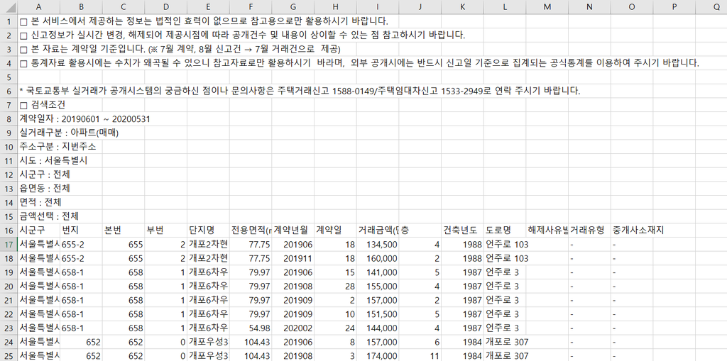

파일의 앞 부분에는 자료에 대한 정보들이 설명되어 있으며 자료는 16번째 줄부터 시작합니다.

따라서 아래와 같이 `skip=15`를 이용하여 15줄을 건너뛰겠습니다.

또한 16번째 줄이 변수의 이름이므로 `header=T`를 설정하겠습니다..

```r
apt1 <-read.csv("C:/Users/stats/Downloads/apt2020.csv", skip=15, header=T)
apt2 <-read.csv("C:/Users/stats/Downloads/apt2021.csv", skip=15, header=T)
apt3 <-read.csv("C:/Users/stats/Downloads/apt2022.csv", skip=15, header=T)
```

불러온 자료는 head, tail, summary, str, dim, View 등을 통해 확인이 가능합니다.

```r
head(apt1)
```

```
##                     시군구  번지 본번 부번                   단지명 전용면적...
## 1 서울특별시 강남구 개포동 655-2 0655 0002   개포2차현대아파트(220)       77.75
## 2 서울특별시 강남구 개포동 655-2 0655 0002   개포2차현대아파트(220)       77.75
## 3 서울특별시 강남구 개포동 658-1 0658 0001 개포6차우성아파트1동~8동       79.97
## 4 서울특별시 강남구 개포동 658-1 0658 0001 개포6차우성아파트1동~8동       79.97
## 5 서울특별시 강남구 개포동 658-1 0658 0001 개포6차우성아파트1동~8동       79.97
## 6 서울특별시 강남구 개포동 658-1 0658 0001 개포6차우성아파트1동~8동       79.97
##   계약년월 계약일 거래금액.만원. 층 건축년도     도로명 해제사유발생일 거래유형
## 1   201906     18        134,500  4     1988 언주로 103             NA        -
## 2   201911     18        160,000  2     1988 언주로 103             NA        -
## 3   201906     15        141,000  5     1987   언주로 3             NA        -
## 4   201908     28        155,000  4     1987   언주로 3             NA        -
## 5   201909      2        157,000  2     1987   언주로 3             NA        -
## 6   201909     10        151,500  5     1987   언주로 3             NA        -
##   중개사소재지
## 1            -
## 2            -
## 3            -
## 4            -
## 5            -
## 6            -
```

```r
head(apt2)
```

```
##                     시군구  번지 본번 부번                   단지명 전용면적...
## 1 서울특별시 강남구 개포동 655-2 0655 0002   개포2차현대아파트(220)       77.75
## 2 서울특별시 강남구 개포동 655-2 0655 0002   개포2차현대아파트(220)       77.75
## 3 서울특별시 강남구 개포동 658-1 0658 0001 개포6차우성아파트1동~8동       79.97
## 4 서울특별시 강남구 개포동 658-1 0658 0001 개포6차우성아파트1동~8동       79.97
## 5 서울특별시 강남구 개포동 658-1 0658 0001 개포6차우성아파트1동~8동       79.97
## 6 서울특별시 강남구 개포동 658-1 0658 0001 개포6차우성아파트1동~8동       67.28
##   계약년월 계약일 거래금액.만원. 층 건축년도     도로명 해제사유발생일 거래유형
## 1   202006     23        149,500  4     1988 언주로 103             NA        -
## 2   202104     15        174,000  9     1988 언주로 103             NA        -
## 3   202006     18        162,750  4     1987   언주로 3             NA        -
## 4   202006     20        160,000  5     1987   언주로 3             NA        -
## 5   202006     22        150,000  2     1987   언주로 3             NA        -
## 6   202006     25        165,000  2     1987   언주로 3       20200831        -
##   중개사소재지
## 1            -
## 2            -
## 3            -
## 4            -
## 5            -
## 6            -
```

```r
head(apt3)
```

```
##                     시군구  번지 본번 부번                   단지명 전용면적...
## 1 서울특별시 강남구 개포동 658-1 0658 0001 개포6차우성아파트1동~8동       79.97
## 2 서울특별시 강남구 개포동 658-1 0658 0001 개포6차우성아파트1동~8동       79.97
## 3 서울특별시 강남구 개포동 658-1 0658 0001 개포6차우성아파트1동~8동       79.97
## 4 서울특별시 강남구 개포동 658-1 0658 0001 개포6차우성아파트1동~8동       79.97
## 5 서울특별시 강남구 개포동 658-1 0658 0001 개포6차우성아파트1동~8동       79.97
## 6 서울특별시 강남구 개포동 658-1 0658 0001 개포6차우성아파트1동~8동       79.97
##   계약년월 계약일 거래금액.만원. 층 건축년도   도로명 해제사유발생일 거래유형
## 1   202108     11        200,000  3     1987 언주로 3             NA        -
## 2   202109      2        220,000  2     1987 언주로 3             NA        -
## 3   202112      4        215,000  3     1987 언주로 3             NA 중개거래
## 4   202204     12        220,000  4     1987 언주로 3             NA 중개거래
## 5   202204     21        220,000  2     1987 언주로 3             NA 중개거래
## 6   202205     27        216,000  2     1987 언주로 3             NA 중개거래
##   중개사소재지
## 1            -
## 2            -
## 3  서울 강남구
## 4  서울 강남구
## 5  서울 강남구
## 6  서울 강남구
```

```r
dim(apt1)
```

```
## [1] 90725    15
```

```r
dim(apt2)
```

```
## [1] 78182    15
```

```r
dim(apt3)
```

```
## [1] 27791    15
```

rbind를 이용하거나 **dplyr** 패키지의 bind_rows를 이용하면 하나의 데이터로 합칠 수 있습니다.

```r
t.apt1 <- rbind(apt1, apt2, apt3)
dim(t.apt1)
```

```
## [1] 196698     15
```

```r
library(dplyr)
t.apt2 <- bind_rows(apt1, apt2, apt3)
dim(t.apt2)
```

```
## [1] 196698     15
```

이제 2019년 6월 1일부터 2022년 5월 31일까지 서울특별시 아파트 거래정보를 분석해보겠습니다.

### 2. Tidy

**dplyr** 패키지를 이용하여 자료를 정리해보겠습니다.

- 분석에 앞서 시군구 “시 + 구 + 동”으로 구성되어 있어 strsplit함수의 구분자를 빈칸으로 설정하겠습니다.

```
strsplit : 구분자를 이용하여 문자열을 나누는 함수
```

```r
strsplit(t.apt1$시군구[1], split=" ")
```

```
## [[1]]
## [1] "서울특별시" "강남구"     "개포동"
```

```r
out <- strsplit(t.apt1$시군구, split=" ")
region <- do.call(rbind, out) %>% data.frame
names(region)<-c("시","구","동")
t.apt3 <- cbind(t.apt1, region)
head(t.apt3)
```

```
##                     시군구  번지 본번 부번                   단지명 전용면적...
## 1 서울특별시 강남구 개포동 655-2 0655 0002   개포2차현대아파트(220)       77.75
## 2 서울특별시 강남구 개포동 655-2 0655 0002   개포2차현대아파트(220)       77.75
## 3 서울특별시 강남구 개포동 658-1 0658 0001 개포6차우성아파트1동~8동       79.97
## 4 서울특별시 강남구 개포동 658-1 0658 0001 개포6차우성아파트1동~8동       79.97
## 5 서울특별시 강남구 개포동 658-1 0658 0001 개포6차우성아파트1동~8동       79.97
## 6 서울특별시 강남구 개포동 658-1 0658 0001 개포6차우성아파트1동~8동       79.97
##   계약년월 계약일 거래금액.만원. 층 건축년도     도로명 해제사유발생일 거래유형
## 1   201906     18        134,500  4     1988 언주로 103             NA        -
## 2   201911     18        160,000  2     1988 언주로 103             NA        -
## 3   201906     15        141,000  5     1987   언주로 3             NA        -
## 4   201908     28        155,000  4     1987   언주로 3             NA        -
## 5   201909      2        157,000  2     1987   언주로 3             NA        -
## 6   201909     10        151,500  5     1987   언주로 3             NA        -
##   중개사소재지         시     구     동
## 1            - 서울특별시 강남구 개포동
## 2            - 서울특별시 강남구 개포동
## 3            - 서울특별시 강남구 개포동
## 4            - 서울특별시 강남구 개포동
## 5            - 서울특별시 강남구 개포동
## 6            - 서울특별시 강남구 개포동
```

- 월별 거래내역을 확인하기 위해 계약년월을 `mutate`과 `substr`을 이용하여 구분하겠습니다.

```r
t.apt3 %>%
  mutate(year=substr(계약년월,1,4), mon=substr(계약년월,5,6)) -> t.apt4
```

- 거래금액에 **,**가 있어 숫자가 아닌 문자료 처리되고 있습이다.
- gsub와 as.numeric을 이용하여 숫치형 자료로 변환하겠습니다.

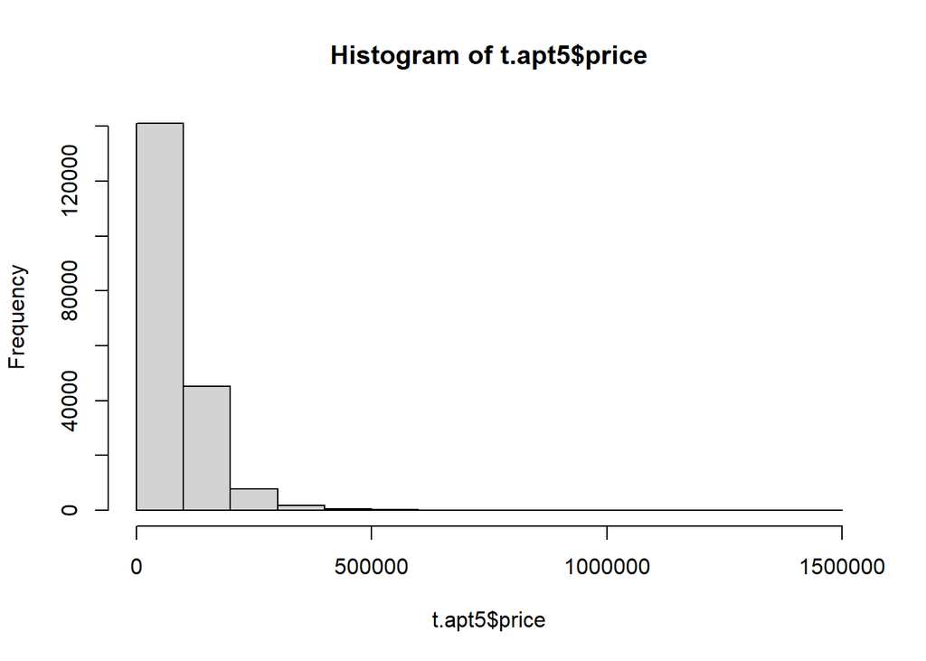

```r
t.apt4 %>%
  mutate(price=gsub(",","",`거래금액.만원.`)) %>%
  mutate(price=as.numeric(price)) -> t.apt5

hist(t.apt5$price)
```

### Q1. 연도별, 월별 서울특별시 아파트 거래량은?

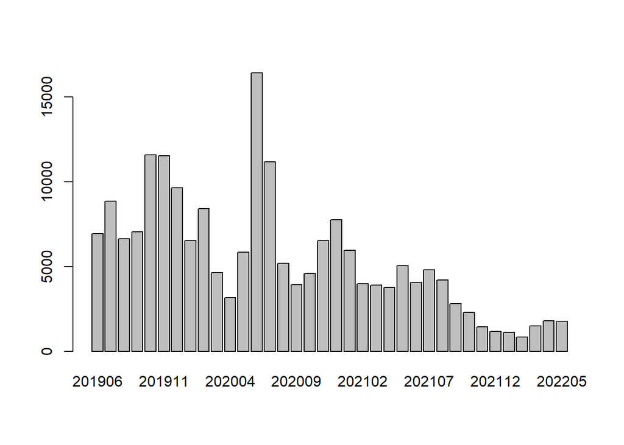

```r
t.apt5$계약년월 %>% table %>% barplot
```

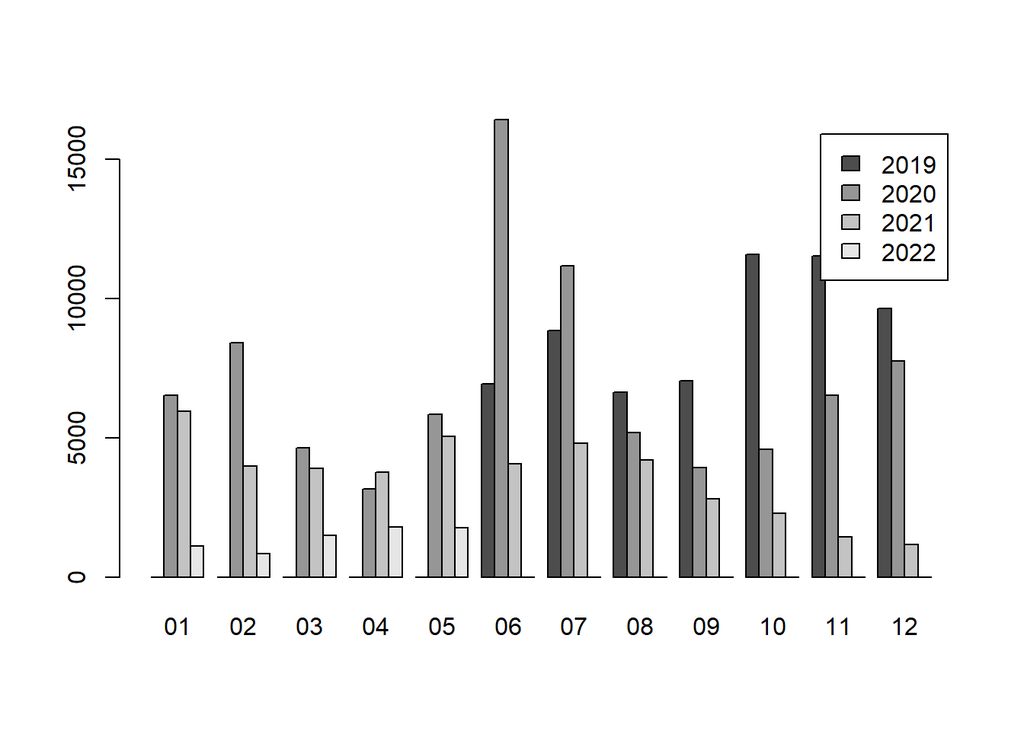

```r
table(t.apt5$year, t.apt5$mon) %>% barplot(., beside=T, legend=rownames(.))
```

### Q2. 가장 비싸게 거래된 아파트는 언제 거래되었으며 아파트 명은?

```r
t.apt5 %>%
  filter(price==max(price))
```

```
##                     시군구 번지 본번 부번 단지명 전용면적... 계약년월 계약일
## 1 서울특별시 강남구 청담동  129 0129 0000  PH129      273.96   202204     28
##   거래금액.만원. 층 건축년도          도로명 해제사유발생일 거래유형
## 1      1,450,000 16     2020 압구정로79길 88             NA   직거래
##   중개사소재지         시     구     동 year mon   price
## 1            - 서울특별시 강남구 청담동 2022  04 1450000
```

### Q3. 2020년과 월별 송파구의 평균 계약건수와 평균 거래금액은?

```r
t.apt5 %>%
  filter(year==2020) %>%
  filter(구=="송파구") %>%
  group_by(mon) %>%
  summarise(n=n(), mean=mean(price), sd=sd(price))
```

```
## # A tibble: 12 x 4
##    mon       n    mean     sd
##    <chr> <int>   <dbl>  <dbl>
##  1 01      221 103041. 49943.
##  2 02      363 119380. 51819.
##  3 03      154 111053. 56545.
##  4 04      144 123385. 56775.
##  5 05      357 139018. 52046.
##  6 06     1183 135015. 53831.
##  7 07      583 117935. 48967.
##  8 08      291 119237. 50494.
##  9 09      231 130657. 53401.
## 10 10      237 131103. 56256.
## 11 11      380 138090. 54921.
## 12 12      486 155546. 61933.
```

### Q4. 2021년과 월별 송파구의 평균 계약건수와 평균 거래금액은?

```r
t.apt5 %>%
  filter(year==2021) %>%
  filter(구=="송파구") %>%
  group_by(mon) %>%
  summarise(n=n(), mean=mean(price), sd=sd(price))
```

```
## # A tibble: 12 x 4
##    mon       n    mean     sd
##    <chr> <int>   <dbl>  <dbl>
##  1 01      269 150920. 67853.
##  2 02      204 144106. 69403.
##  3 03      157 149505. 72525.
##  4 04      215 153927. 69910.
##  5 05      251 145126. 63830.
##  6 06      163 150109. 68198.
##  7 07      257 159365. 67675.
##  8 08      212 166849. 70953.
##  9 09      171 171937. 70408.
## 10 10      105 155259. 74845.
## 11 11       60 171080. 92203.
## 12 12       67 136440. 81395.
```

### Q5. 평균 아파트 거래금액이 높은 지역은?

```r
t.apt5 %>%
  group_by(시군구) %>%
  summarise(n=n(), mean=mean(price)) %>%
  arrange(-mean)
```

```
## # A tibble: 332 x 3
##    시군구                          n    mean
##    <chr>                       <int>   <dbl>
##  1 서울특별시 종로구 신문로2가     4 321500
##  2 서울특별시 강남구 압구정동    904 310928.
##  3 서울특별시 서초구 반포동     1777 282143.
##  4 서울특별시 용산구 한남동      515 252107.
##  5 서울특별시 용산구 용산동5가    91 250783.
##  6 서울특별시 강남구 대치동     1316 224844.
##  7 서울특별시 용산구 서빙고동    135 219373.
##  8 서울특별시 강남구 청담동      555 217165.
##  9 서울특별시 강남구 도곡동     1573 215992.
## 10 서울특별시 서초구 잠원동     1408 210994.
## # ... with 322 more rows
```

### Q6. 아파트 나이별 평균 거래가격은?

```r
t.apt5 %>%
  mutate(age=as.numeric(year)-건축년도) %>%
  group_by(age) %>%
  summarise(n=n(), mean=mean(price))
```

```
## # A tibble: 62 x 3
##      age     n    mean
##    <dbl> <int>   <dbl>
##  1    -2     4  71133.
##  2    -1    89  33791.
##  3     0  3118  55259.
##  4     1  3341  98677.
##  5     2  3274 117159.
##  6     3  3640 120001.
##  7     4  3533 119061.
##  8     5  3813 105074.
##  9     6  3769  93568.
## 10     7  3884  84681.
## # ... with 52 more rows
```

### Q7. 거래면적의 시군구별, 계약년월별 거래 건수와 평균거래 금액은?

```r
t.apt5 %>%
  mutate(py=`전용면적...`/3.3) %>%
  mutate(py.c=cut(py,c(0,10,20,30,40,50,60,500))) -> t.apt6

t.apt6 %>%
  group_by(계약년월, 시군구, py.c) %>%
  summarise(n=n(), mean=mean(price))
```

```
## # A tibble: 25,999 x 5
## # Groups:   계약년월, 시군구 [9,147]
##    계약년월 시군구                   py.c        n    mean
##       <int> <chr>                    <fct>   <int>   <dbl>
##  1   201906 서울특별시 강남구 개포동 (10,20]    49 148544.
##  2   201906 서울특별시 강남구 개포동 (20,30]    25 178604.
##  3   201906 서울특별시 강남구 개포동 (30,40]     8 207750
##  4   201906 서울특별시 강남구 개포동 (40,50]     1 210000
##  5   201906 서울특별시 강남구 개포동 (50,60]     5 229000
##  6   201906 서울특별시 강남구 논현동 (10,20]     5  53500
##  7   201906 서울특별시 강남구 논현동 (20,30]    13 126808.
##  8   201906 서울특별시 강남구 논현동 (30,40]     4 123625
##  9   201906 서울특별시 강남구 논현동 (40,50]     1  81000
## 10   201906 서울특별시 강남구 대치동 (10,20]    14 126643.
## # ... with 25,989 more rows
```

### Q8. 강동구에서 평균거래금액이 가장 높은 아파트 단지 5개는?

```r
t.apt6 %>%
  filter(구=="강동구") %>%
  group_by(단지명) %>%
  summarise(n=n(), mean=mean(price)) %>%
  arrange(-mean) %>%
  head(5)
```

```
## # A tibble: 5 x 3
##   단지명            n    mean
##   <chr>         <int>   <dbl>
## 1 파크뷰캐슬        1 213000
## 2 현대코럴          5 157900
## 3 둔촌주공4단지    41 157687.
## 4 둔촌주공3단지    22 152955.
## 5 둔촌주공2단지    13 152538.
```

### Q9. 요일별 거래건수는?

```r
t.apt6 %>%
  mutate(date1 = as.Date(paste0(year,"-",mon,"-",계약일))) %>%
  mutate(weekday = weekdays(date1)) %>%
  group_by(weekday) %>%
  summarise(n=n())
```

```
## # A tibble: 7 x 2
##   weekday     n
##   <chr>   <int>
## 1 금요일  27641
## 2 목요일  25956
## 3 수요일  27470
## 4 월요일  29599
## 5 일요일   8813
## 6 토요일  48792
## 7 화요일  28427
```